# Kenya Soil Health Study Analysis

Matt Lowes

```r
rm(list = ls())
cat("\014")
```

```r
## set up some global options
# always set stringsAsFactors = F when loading data
options(stringsAsFactors=FALSE)

# show the code
knitr::opts_chunk$set(echo = TRUE)

# define all knitr tables to be html format
options(knitr.table.format = 'html')

# change code chunk default to not show warnings or messages
knitr::opts_chunk$set(warning = FALSE, message = FALSE)

libs <- c("tidyverse", "knitr", "readxl",
    "sp", "dismo", "leaflet", "kableExtra")
#"NbClust", "clValid", "ggfortify", "clustree", "dendextend", "FactoMineR", "corrplot", "GGally"
lapply(libs, require, character.only = T, quietly = T, warn.conflicts = F)
```

[output not shown]

```r
#### define helpful functions
# define function to adjust table widths
html_table_width <- function(kable_output, width) {
  width_html <- paste0(paste0('<col width="', width, '">'), collapse = "\n")
  sub("<table>", paste0("<table>\n", width_html), kable_output)
}

source("../../oaflib/commcareExport.R")
source("../../oaflib/misc.R")
source("../../oaflib/plm.R")
select <- dplyr::select

forceUpdateAll <- FALSE
```

# Background

This file will pick up on from the Kenya round 1 file and finish the analysis. The cleaning of the data up through the round 1 data (baseline and round 1) happens in the `kenya_round_1` folder. Going forward, the cleaning of new data will happen in the `shs_cleaning.R` file, which I’ll source here, and then the analysis will happen here.

# Objective

Analyze the soil health study data.

# Data

```r
# load the latest kenya data from the cleaning file >> or maybe do the combining there.
#source("shs_cleaning.R")

keDat <- readRDS("ke_cleaned_combined_fieldDat.rds")
rwDat <- readRDS("rw_cleaned_combined_fieldDat.rds")
```

# Analysis

## Check identifiers

**It’s hard to know where to draw the line between cleaning and analysis. I’m going to keep this code here even though it’s technically additional data cleaning**

Check that we’re actually dealing with clients for which we have multiple records

```r
table(table(rwDat$sample_id)==5)
```

```
##
## FALSE  TRUE
##   157  2328
```

```r
table(table(rwDat$sample_id))
```

```
##
##    1    2    3    4    5
##    1    6  110   40 2328
```

Hm. So the numbers less than 5 could be that we’re just not finding people every year. But the 1s and 2s are particularly strange. Let’s check those out. Here’s a [helpful link](https://stackoverflow.com/questions/41875078/how-to-identify-indexes-of-elements-appearing-only-once-in-a-vector-in-r)

```r
singleSurvey <- names(which(table(rwDat$sample_id) == 1))

rwDat %>%
  filter(sample_id == singleSurvey)
```

| sample_id | season | d_client | d_compost | d_lime | fert_kg1 | fert_kg2 | fert_type1 | fert_type2 | kg_compost | kg_lime | kg_seed_1 | kg_seed_2 | kg_yield_1 | kg_yield_2 | quality_compost | type_compost | date | enum_name | tablet | d_sample | district | cell_field | village | age | n_household | n_tubura_season | n_cows | n_goats | n_chickens | … |
| --- | --- | --- | --- | --- | --- | --- | --- | --- | --- | --- | --- | --- | --- | --- | --- | --- | --- | --- | --- | --- | --- | --- | --- | --- | --- | --- | --- | --- | --- | --- |
| 2175c | 15b | 0 | 1 | 0 | NA | NA | None | None | 150 | NA | 3 | NA | 7 | NA | Good | Ihene | 2015-08-05 | NTAKIRUTIMANA Emmanuel | 21 | 1 | Rutsiro | karambi b | bukiro | 45 | 5 | 0 | 0 | 1 | 0 | … |

Looks like this person was only surveyed in the first season. Okay. Check out the other seasons

```r
twoSurveys <- names(which(table(rwDat$sample_id) == 2))
rwDat %>%
  filter(sample_id %in% twoSurveys)
```

| sample_id | season | d_client | d_compost | d_lime | fert_kg1 | fert_kg2 | fert_type1 | fert_type2 | kg_compost | kg_lime | kg_seed_1 | kg_seed_2 | kg_yield_1 | kg_yield_2 | quality_compost | type_compost | date | enum_name | tablet | d_sample | district | cell_field | village | age | n_household | n_tubura_season | n_cows | n_goats | n_chickens | … |
| --- | --- | --- | --- | --- | --- | --- | --- | --- | --- | --- | --- | --- | --- | --- | --- | --- | --- | --- | --- | --- | --- | --- | --- | --- | --- | --- | --- | --- | --- | --- |
| 1295 | 17a | NA | NA | NA | NA | NA | NA | NA | NA | NA | NA | NA | NA | NA | NA | NA | NA | Uwamungu Delphine | NA | NA | NA | NA | NA | NA | NA | NA | NA | NA | NA | … |
| 1295 | 17b | NA | NA | NA | NA | NA | NA | NA | NA | NA | NA | NA | NA | NA | NA | NA | NA | Uwamungu Delphine | NA | NA | NA | NA | NA | NA | NA | NA | NA | NA | NA | … |
| 1295c | 17a | NA | NA | NA | NA | NA | NA | NA | NA | NA | NA | NA | NA | NA | NA | NA | NA | Uwamungu Delphine | NA | NA | NA | NA | NA | NA | NA | NA | NA | NA | NA | … |
| 1295c | 17b | NA | NA | NA | NA | NA | NA | NA | NA | NA | NA | NA | NA | NA | NA | NA | NA | Uwamungu Delphine | NA | NA | NA | NA | NA | NA | NA | NA | NA | NA | NA | … |
| 1298c | 17a | NA | NA | NA | NA | NA | NA | NA | NA | NA | NA | NA | NA | NA | NA | NA | NA | Uwamungu Delphine | NA | NA | NA | NA | NA | NA | NA | NA | NA | NA | NA | … |
| 1298c | 17b | NA | NA | NA | NA | NA | NA | NA | NA | NA | NA | NA | NA | NA | NA | NA | NA | Uwamungu Delphine | NA | NA | NA | NA | NA | NA | NA | NA | NA | NA | NA | … |
| 1300 | 17a | 1 | 1 | no_lime | NA | NA | None | None | 50 | NA | 4.5 | NA | 20 | NA | Average | goat | 2017-08-09 | Uwamungu Delphine | NA | NA | Karongi | Kibirizi | Kamusanganya | 32 | 4 | NA | 0 | 2 | 0 | … |
| 1300 | 17b | 1 | NA | NA | NA | NA | NA | NA | NA | NA | NA | NA | NA | NA | NA | NA | 2017-08-09 | Uwamungu Delphine | NA | NA | Karongi | Kibirizi | Kamusanganya | 32 | 4 | NA | 0 | 2 | 0 | … |
| 1437 | 17a | 1 | 1 | no_lime | NA | NA | None | None | 800 | NA | 12 | NA | 80 | NA | Average | cow | 2017-07-28 | Murekatete Esther | NA | NA | Karongi | Kibirizi | Kamusanganya | 37 | 2 | NA | 2 | 2 | 0 | … |
| 1437 | 17b | 1 | 1 | no_lime | NA | NA | None | NA | 400 | NA | 12 | NA | 60 | NA | Average | cow | 2017-07-28 | Murekatete Esther | NA | NA | Karongi | Kibirizi | Kamusanganya | 37 | 2 | NA | 2 | 2 | 0 | … |

[output cut: 2 more lines]

Okay, these are from the recent round but they don’t have any previous surveys which is odd. We shouldn’t be adding new farmers into the survey. These can be dropped for simplicity. I can follow up with Eric and Cyprien to find out the issue but I’m just going to drop them for now.

```r
rwDat <- rwDat %>%
  filter(!sample_id %in% twoSurveys)
```

```r
fourSurveys <- names(which(table(rwDat$sample_id)==4))
rwDat %>%
  filter(sample_id %in% fourSurveys)
```

| sample_id | season | d_client | d_compost | d_lime | fert_kg1 | fert_kg2 | fert_type1 | fert_type2 | kg_compost | kg_lime | kg_seed_1 | kg_seed_2 | kg_yield_1 | kg_yield_2 | quality_compost | type_compost | date | enum_name | tablet | d_sample | district | cell_field | village | age | n_household | n_tubura_season | n_cows | n_goats | n_chickens | … |
| --- | --- | --- | --- | --- | --- | --- | --- | --- | --- | --- | --- | --- | --- | --- | --- | --- | --- | --- | --- | --- | --- | --- | --- | --- | --- | --- | --- | --- | --- | --- |
| 1034c | 16a | NA | 1 | no_lime | NA | 0 | None | NA | 90 | NA | N |  | NA |  | Good | cow | 2016-08-04 | Constance Nyiranjamahoro | 30 | 1 | Nyamasheke | Ninzi | Gikuyu | 71 | 1 | not_a_client_3seasons | 1 | 0 | 0 | … |
| 1034c | 16b | 0 | 1 | no_lime | NA | 0 | None | NA | 90 | NA | 1 |  | 12 | NA | Good | cow | 2016-08-04 | Constance Nyiranjamahoro | 30 | 1 | Nyamasheke | Ninzi | Gikuyu | 71 | 1 | not_a_client_3seasons | 1 | 0 | 0 | … |
| 1207c | 16a | NA | NA | NA | NA | NA | NA | NA | NA | NA | N |  | NA |  | NA | NA | 2016-08-17 | Antoinette Uwizeye | NA | 1 | Karongi | BiramboA | nyakibuguma | 68 | 9 | not_a_client_3seasons | 1 | 0 | 0 | … |
| 1207c | 16b | 0 | NA | NA | NA | NA | NA | NA | NA | NA | NA |  | NA | NA | NA | NA | 2016-08-17 | Antoinette Uwizeye | NA | 1 | Karongi | BiramboA | nyakibuguma | 68 | 9 | not_a_client_3seasons | 1 | 0 | 0 | … |
| 1227c | 16a | NA | 1 | no_lime | NA | 0 | None | NA | 200 | NA | N |  | NA |  | Average | cow | 2016-08-07 | yankurije ange | 3 | 1 | Karongi | birambo a | ntarabana | 61 | 7 | not_a_client_3seasons | 0 | 0 | 0 | … |
| 1227c | 16b | 0 | 1 | no_lime | NA | 0 | None | NA | 100 | NA | 4 |  | 6 | NA | Average | cow | 2016-08-07 | yankurije ange | 3 | 1 | Karongi | birambo a | ntarabana | 61 | 7 | not_a_client_3seasons | 0 | 0 | 0 | … |
| 1300c | 16a | NA | 1 | no_lime | NA | 0 | None | NA | 350 | NA | N | NA | NA | NA | Average | cow | 2016-08-11 | uwamungu Delphine | 4 | 1 | Karongi | Kibirizi | Kamusanganya | 43 | 4 | not_a_client_3seasons | 0 | 0 | 0 | … |
| 1300c | 16b | 0 | 1 | no_lime | NA | 0 | None | NA | 300 | NA | 3 | NA | 15 | NA | Average | cow | 2016-08-11 | uwamungu Delphine | 4 | 1 | Karongi | Kibirizi | Kamusanganya | 43 | 4 | not_a_client_3seasons | 0 | 0 | 0 | … |
| 1366c | 16a | NA | 0 | no_lime | NA | 0 | None | NA | NA | NA | N |  | NA |  | NA | NA | 2016-09-05 | uwamungu Delphine | 4 | 1 | Karongi | Karambo | Bandamiko | 72 | 4 | not_a_client_3seasons | 1 | 4 | 0 | … |
| 1366c | 16b | 0 | 1 | no_lime | NA | 0 | None | NA | 150 | NA | 8 |  | 20 | NA | Average | cow | 2016-09-05 | uwamungu Delphine | 4 | 1 | Karongi | Karambo | Bandamiko | 72 | 4 | not_a_client_3seasons | 1 | 4 | 0 | … |

[output cut: 150 more lines]

Okay. There are enough surveys in the 3 and 4 category that they’re at least plausible from a data quality and survey strategy perspective. I’ll leave them as they are.

## Surveys for which we don’t have soil

Check that there isn’t something systematic in these surveys. If so, describe what it is.

### Attrition analysis for appendix

Create a record of how many farmers are joining and leaving Tubura between the baseline through the current survey round. These numbers only reflect the changes from the last round.

**This also should account for clients that we miss in each season so we can say what the attrition has been season to season. Also, why don’t we have 16A results for Rwanda. Find out what’s happening there.**

```r
clientCount <- function(dat){
  # this assumes season, d_client, and sample_id remain the names of
  # the key variables. They should for the data to match.

  # this funciton tablulates the number of clients in each season
  iniTab <- dat %>%
    filter(!is.na(d_client)) %>%
    group_by(season, d_client) %>%
    tally() %>%
    gather(key, value, -c(season, d_client)) %>%
    spread(d_client, value) %>%
    rename(control = `0`,
         client = `1`) %>%
    mutate(control = as.numeric(control),
         client = as.numeric(client)) %>%
    rowwise() %>%
    mutate(total = sum(control, client)) %>%
    ungroup()

  percentDiff <- iniTab %>%
    mutate(pct_change = (((total - lead(total))/total) * 100))
  return(percentDiff)

}

rw.attrition.tab <- clientCount(rwDat)

ke.attrition.tab <- clientCount(keDat)
```

```r
attritionRate <- function(org, new){
  return((org - new)/org * 100)
}


attritionRate(2028, 1935)  # kenya
```

```
## [1] 4.585799
```

```r
attritionRate(2439, 2409) # rwanda
```

```
## [1] 1.230012
```

```r
attritionRate(4467, 4344) # total
```

```
## [1] 2.753526
```

## Soil graphs

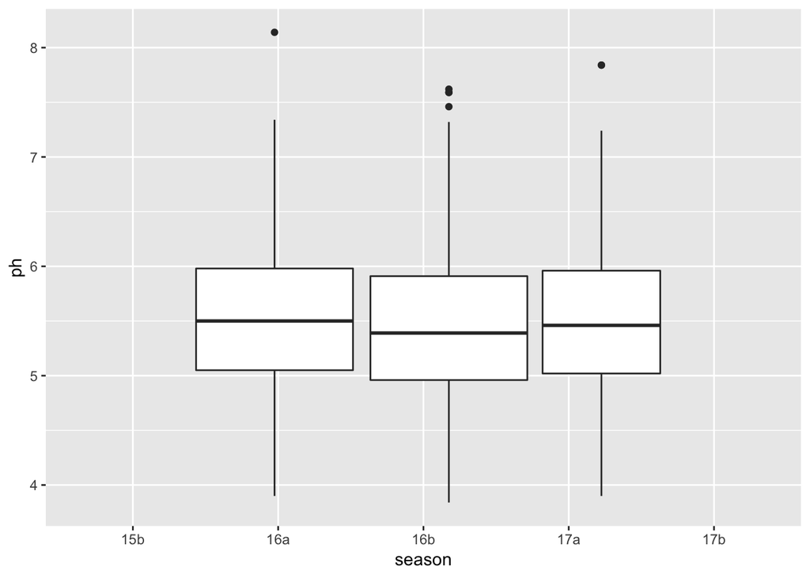

```r
ggplot(rwDat, aes(x = season, y = ph, group = d_client)) + geom_boxplot()
```

### Variable check

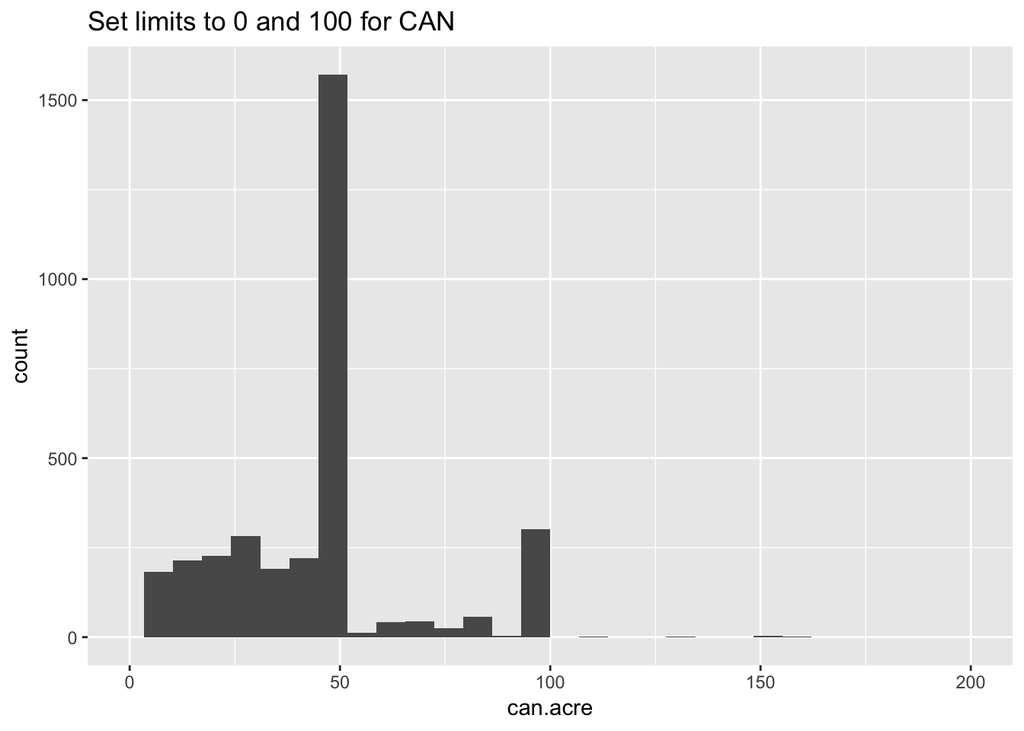

```r
ggplot(keDat, aes(x = can.acre)) +
  geom_histogram() +
  scale_x_continuous(limits = c(0,200)) +
  labs(title = "Set limits to 0 and 100 for CAN")
```

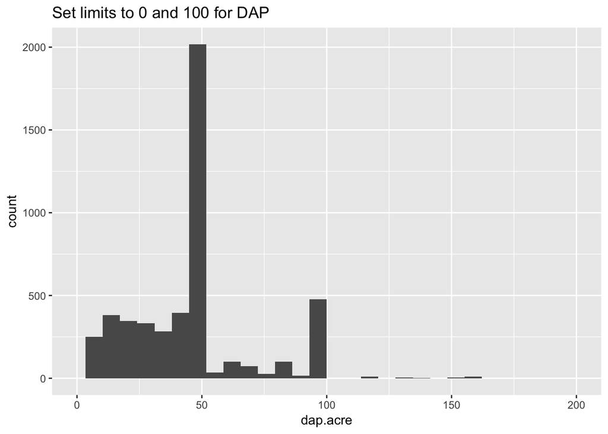

```r
ggplot(keDat, aes(x = dap.acre)) +
  geom_histogram() +
  scale_x_continuous(limits = c(0,200)) +
  labs(title = "Set limits to 0 and 100 for DAP")
```

```r
#export data for Diego >> this is the easiest way to have the location and soil information together. The soil data is also available through the warehouse but it isn't easily connected to the survey information.

rwDat %>%
  select(sample_id, season, district, cell_field, village, ph, calcium, magnesium, organic.carbon, total.nitrogen) %>%
  write_csv(., "output/rwanda_soil_values_travertine_impact.csv")
```

Check values for upcoming final round of Kenya SHS data collection

### Regressions

See [sketch of SHS report](https://docs.google.com/document/d/1koNsKzx97_3rpkGeJI6PnPdYNMdV9q4e-cPQxAWDeDk/edit). Remember that `sameStatus` are the farmers that kept their status between baseline and endline. The two models of interest are:

- Individual fixed effects account for things specific to farmer that don’t change over time
- can control for unobserved sources of heterogeneity over time, very sensitive to model
- add in other data points that do change over time
- so add in things that change over time that plausibly affect our outcome
- fertilizer and seed use are synonymous with being a client or not, highly endogenous
- run two regs
- one with oaf
- one with oaf and fertilizer
- things like slope are collinear
- individual fixed effects makes more sense than using PSM now that we have multiple years.
- means by directional changes
- papers using fixed effects by Miguel on whether changes to rural to urban areas and income

[Helpful link](https://www.r-bloggers.com/how-to-go-parallel-in-r-basics-tips/) for executing code in parallel

# Nitrogen effect

Before running the full models, I’m going to take a closer look at the nitrogen data to make sure we can explain the negative effects we’re seeing in Kenya in the models below. There isn’t a clear agronomic explanation for the negative effect and as a consequence we’re put in a bind in our reporting to explain either the outcome or the modeling.

Let’s start with looking at the relationship between nitrogen and other features to make sure we’re seeing what expect. Here are the notes from Step:

- We might expect that increased application of fertilizer N by our clients could build up organic N because some of the fertilizer N applied would be retained by microbial immobilisation.
- Carbon hasn’t decreased, so I don’t think we can attribute loss of TSN to loss of SOM.
- A possible explanation is that we have increased mineralization of N by virtue of farmers in our program increasing input of N relative to input of C (compared to control farmers), ultimately resulting in a reduction in organic N through crop uptake, leaching, or denitrification.
  - So takeaway here would be that we need to increase C inputs, rather than N inputs >> we should be able to check this (at least roughly), by looking at farmer reported OM inputs to the fields?

> Click here for compost / acre vs. nitrogen rate effects. The short is that there isn’t a clear trend.
- I think increased crop uptake is more likely than leaching or denitrification - If there was more N leaching, we’d expect to see lower pH (and lime adoption amongst clients was <1% at the time we did sampling, and application rates are in any case very low - 500 kg/ha)
- Our farmers mostly follow our trainings on deep placement micro-dosing, so hopefully denitrification risk is mitigated pretty well.
- Relatedly, it’s possible that that crop uptake is exceeding fertilizer application anyway i.e. we have a nutrient mining problem.
- For yields of 3.9 t/ha (mean for our clients in seasons 2014-17), N removal would be ~70 kg/ha, but our current recommendation (aligned with govt) is ~55 kg/ha (50kg/acre DAP + 50kg/acre CAN).

> Nitrogen application by yield output. The yield values are not making sense between survey rounds. I’ll come back to this.
- Conclusion here would be that we need to increase N inputs (though get just trying to plug the N ‘gap’ in the form of mineral fertilizer doesn’t necessarily result in a balanced nutrient budget e.g. N deposition might supply ~5-10 kg N/ha anyway). I suspect this is the case anyway, because our N rates do seem too low, especially in ratio to our P rates. However, this would only be driving a reduction relative to non-clients if our n application relative to yields achieved is lower. Finally, maybe our farmers are rotating less with legumes than non-farmers, or rotating with legumes that are less prolific in fixing N.

> Look at rotations relative to N rate by 1AF status. It does appear that plots that non-1AF plots receive more legume intercrops. This makes sense given that the 1AF core package emphasizes maize monocrops.

Would love to hear your thoughts - entirely possible I’m missing something here. The most critical question here is whether (i) we’re not applying enough C relative to N, (ii) we’re just not applying enough N. I suspect maybe the answer is both, but I’m wary of assuming it’s the latter and making things worse if the key driver is unbalanced C:N ratios.

### Nitrogen alone

The big takeaway for me from this plot is that there are regular spikes at certain values. That seems odd for a system that should be pretty continuous. Let’s see if that plays out evenly across seasons.

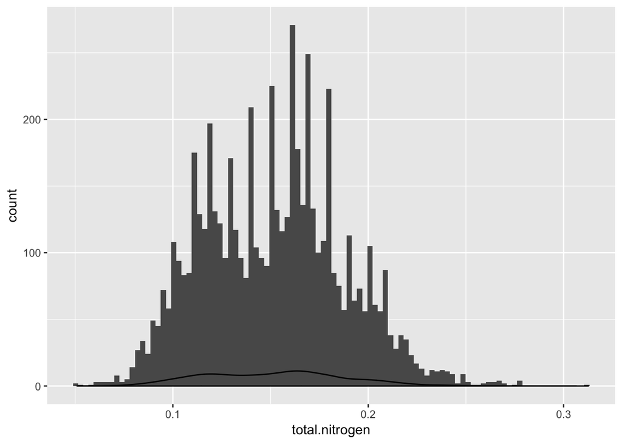

```r
keDat %>%
  ggplot(., aes(x = total.nitrogen)) +
  geom_histogram(bins = 100) +
  geom_density()
```

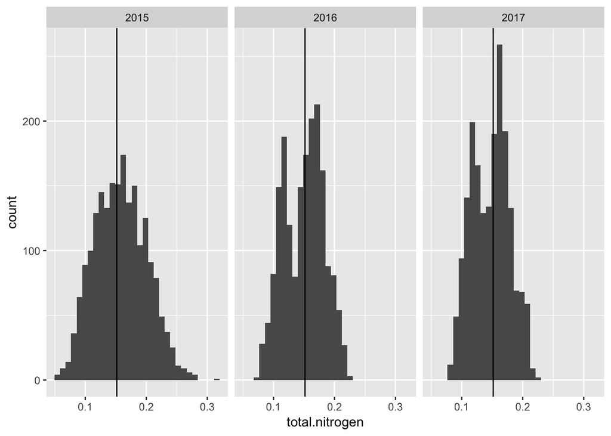

```r
keDat %>%
  ggplot(., aes(x = total.nitrogen)) +
  geom_histogram() +
  geom_vline(xintercept = mean(keDat$total.nitrogen, na.rm = T)) +
  facet_grid(~ season)
```

```r
# ggplot() +
#   geom_histogram(data = filter(keDat, keDat$season == 2015), aes(x = total.nitrogen, fill = 'red'), alpha = 0.5) +
#   geom_histogram(data = filter(keDat, keDat$season == 2016), aes(x = total.nitrogen, fill = 'blue'), alpha = 0.5) +
#   geom_histogram(data = filter(keDat, keDat$season == 2017), aes(x = total.nitrogen, fill = 'green'), alpha = 0.5) +
#   theme(legend.position = 'none')
```

### Nitrogen by season

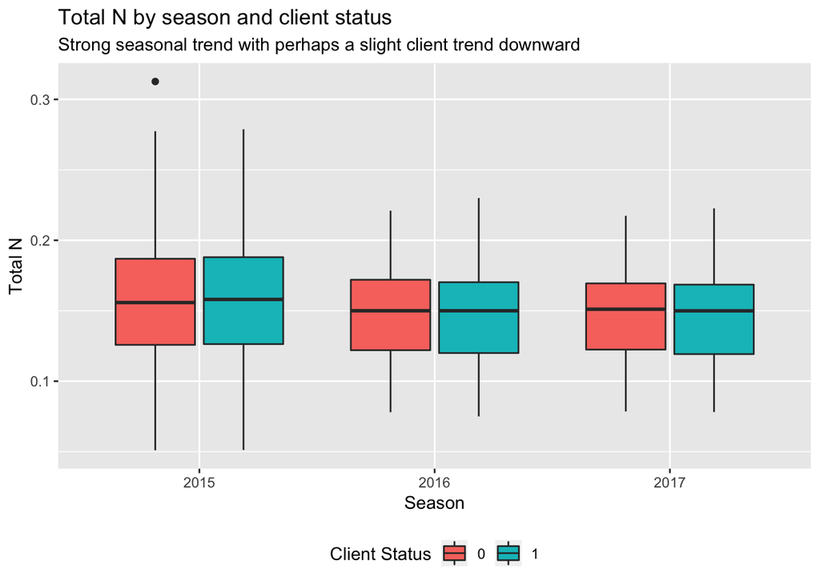

```r
keDat %>%
  #select(season, total.nitrogen, d_client) %>%
  ggplot(., aes(x = season, y = total.nitrogen, fill = as.factor(d_client))) +
  geom_boxplot() +
  theme(legend.position = 'bottom') +
  labs(title = "Total N by season and client status", subtitle ="Strong seasonal trend with perhaps a slight client trend downward",
       x = "Season", y = "Total N", fill = "Client Status")
```

```r
keDat %>%
  filter(!is.na(d_client)) %>%
  group_by(season, d_client) %>%
  summarize(mean = round(mean(total.nitrogen, na.rm = T),4)) %>%
  kable(caption = "Downward average N by season") %>%
  kable_styling(bootstrap_options = c("striped", "hover", "condensed"))
```

Downward average N by season

| season | d_client | mean |
| --- | --- | --- |
| 2015 | 0 | 0.1577 |
| 2015 | 1 | 0.1579 |
| 2016 | 0 | 0.1499 |
| 2016 | 1 | 0.1484 |
| 2017 | 0 | 0.1478 |
| 2017 | 1 | 0.1466 |

1AF clients are slightly below comparison farmers in terms of total nitrogren but the difference is ever so slight. Perhaps in the context of soil chemistry these are big differencs though!

### Nitrogen and carbon

This code also addresses identified erroneous variables.

```r
keDat <- keDat %>%
  mutate(organic.carbon = ifelse(organic.carbon == 0 & total.nitrogen > 0, NA, organic.carbon))
```

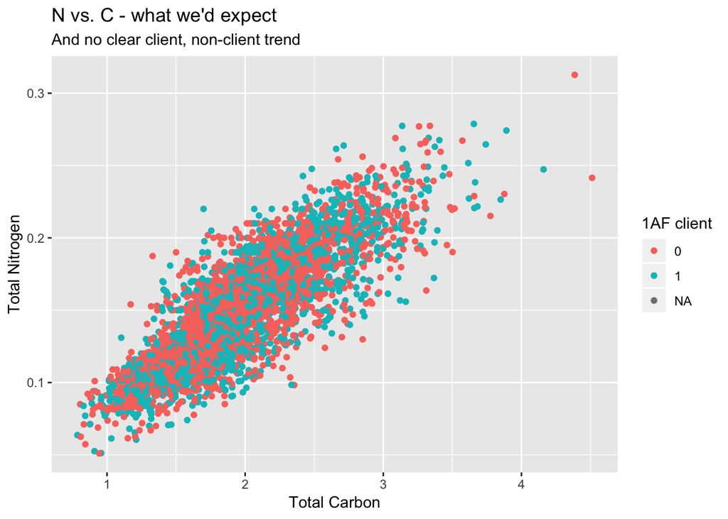

```r
keDat %>%
  ggplot(., aes(x = organic.carbon, y = total.nitrogen, color = as.factor(d_client))) +
  geom_point() +
  labs(title = "N vs. C - what we'd expect", x = "Total Carbon", y = "Total Nitrogen",
       subtitle = "And no clear client, non-client trend", color = "1AF client")
```

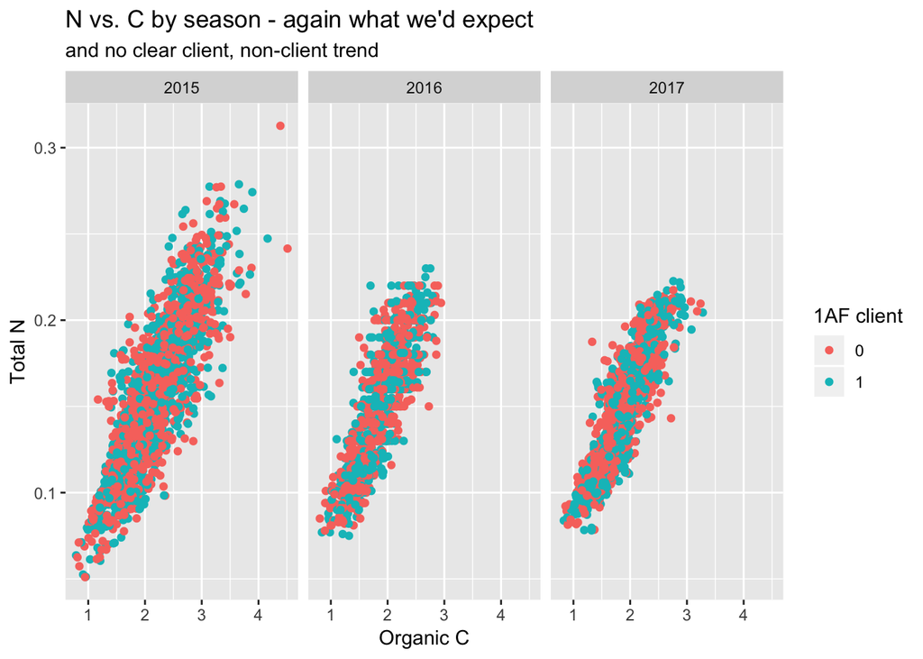

```r
keDat %>%
  filter(!is.na(d_client)) %>%
  ggplot(., aes(x = organic.carbon, y = total.nitrogen, color = as.factor(d_client))) +
  geom_point() +
  labs(title = "N vs. C by season - again what we'd expect", x = "Organic C", y = "Total N", color = "1AF client",
       subtitle = "and no clear client, non-client trend") +
  facet_grid(~ season)
```

This is the same table as above but shows carbon level by season and client status. We don’t see the same gap widening between client and non-client plots that we see with nitrogen.

```r
keDat %>%
  filter(!is.na(d_client)) %>%
  group_by(season, d_client) %>%
  summarize(mean = round(mean(organic.carbon, na.rm = T),4)) %>%
  kable(caption = "Carbon levels trend together by client status over seasons") %>%
  kable_styling(bootstrap_options = c("striped", "hover", "condensed"))
```

Carbon levels trend together by client status over seasons

| season | d_client | mean |
| --- | --- | --- |
| 2015 | 0 | 2.1606 |
| 2015 | 1 | 2.1700 |
| 2016 | 0 | 1.8588 |
| 2016 | 1 | 1.8506 |
| 2017 | 0 | 1.8625 |
| 2017 | 1 | 1.8632 |

### Nitrogen and compost

**if you applied compost since there are so many 0s and removing super large values**

There’s no clear visual trend between compost application and nitrogen rates.

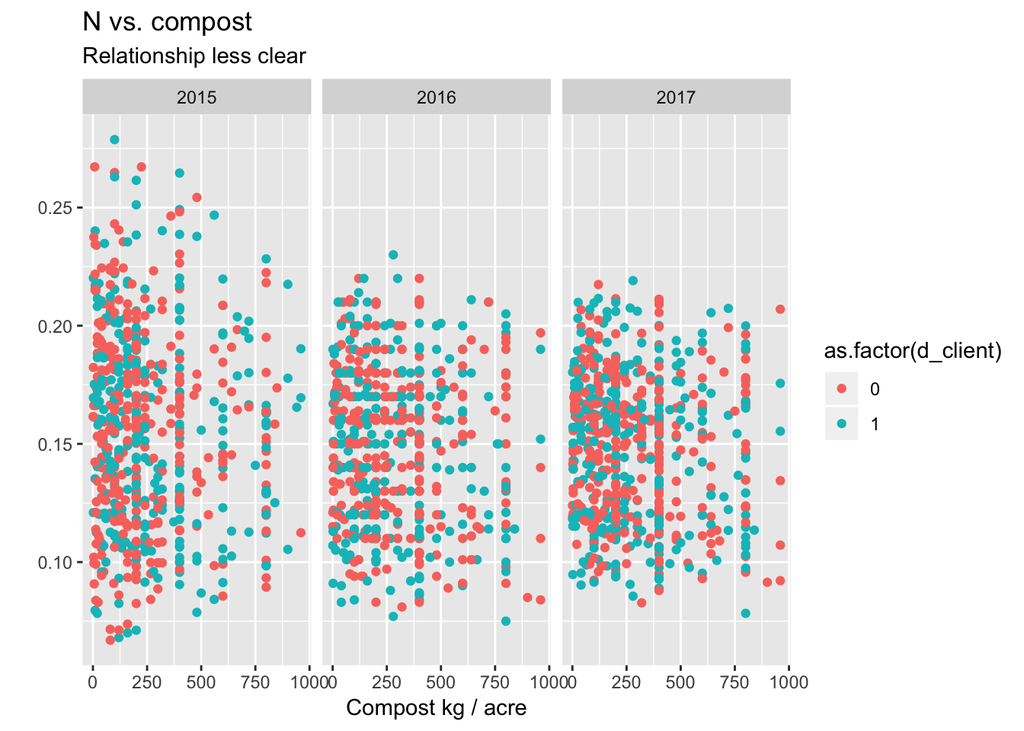

```r
keDat %>%
  filter(compost.acre > 0 & compost.acre < 1000) %>%
  ggplot(., aes(x = compost.acre, y = total.nitrogen, color = as.factor(d_client))) +
  geom_point() +
  facet_grid(~ season) +
  labs(title = "N vs. compost", subtitle = "Relationship less clear", x = "Compost kg / acre", y = "")
```

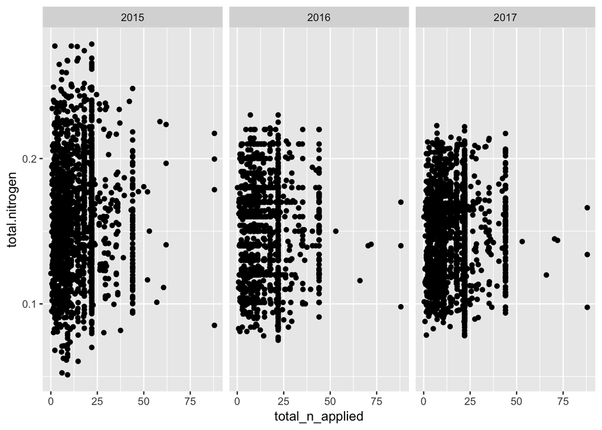

```r
# dap 18% n, can 26%
keDat %>%
  mutate(can_n = can.acre * 0.26,
         dap_n = dap.acre * 0.18) %>%
  rowwise() %>%
  mutate(total_n_applied = sum(can_n, dap_n, na.rm = T)) %>%
  filter(total_n_applied > 0) %>%
  ggplot(., aes(x = total_n_applied, y = total.nitrogen)) +
  geom_point() +
  facet_grid(~ season)
```

**Interpretation**: There doesn’t seem to be a strong relationship between total N applied and total nitrogen in the soil. It’s not clear to me what we should have expected from this relationship but in general I don’t see anything odd.

## Nitrogen by legume rotation and 1AF status

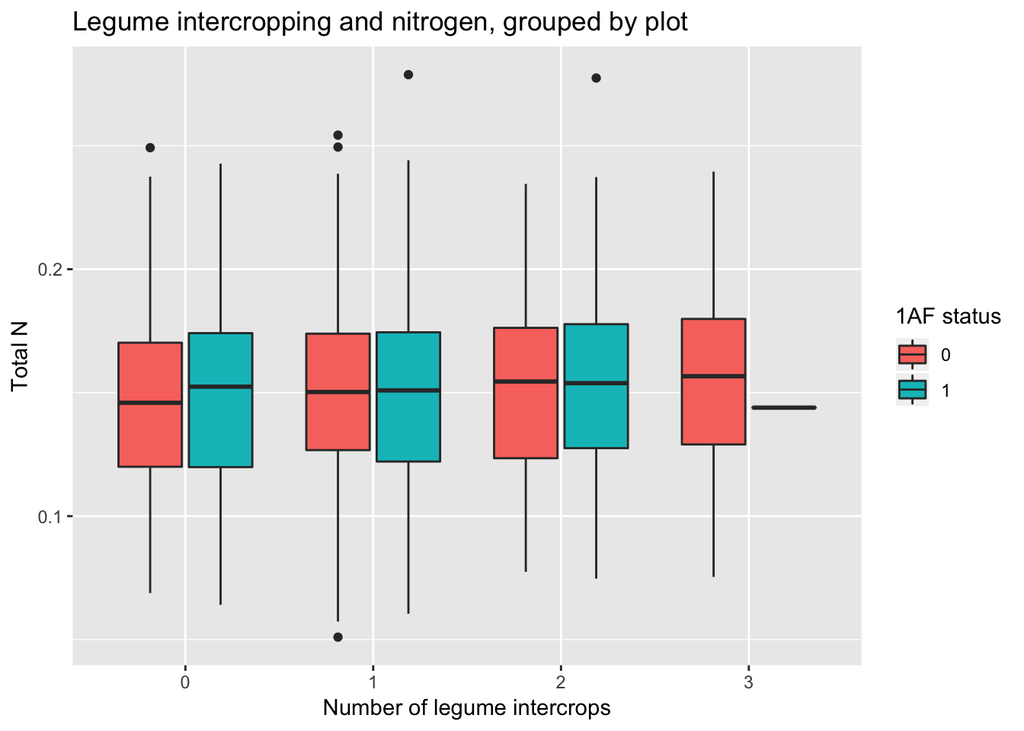

```r
intercrop_check <- keDat %>%
  mutate(legume_intercrop = ifelse(intercrop %in% c("beans", "groundnuts", "soya"), 1, 0))

# intercrop_check %>%
#   ggplot(., aes(x = legume_intercrop, y = total.nitrogen, fill = as.factor(d_client))) +
#   geom_boxplot() +
#   facet_grid(~ season)

# how to check if they used legumes in previous season?


intercrop_check %>%
  group_by(sample_id, d_client) %>%
  summarize(legume_count = sum(legume_intercrop, na.rm = T),
            total.nitrogen.average = mean(total.nitrogen, na.rm = T)) %>%
  filter(legume_count <= 3) %>%
  ggplot(., aes(x = as.factor(legume_count), y = total.nitrogen.average, fill = as.factor(d_client))) +
  geom_boxplot() +
  labs(title = "Legume intercropping and nitrogen, grouped by plot", x = "Number of legume intercrops", y = "Total N", fill = "1AF status")
```

The above plot shows N rates by the number of legume intercrops. It’s not a perfect view of what happens following a season in which a farmer rotates to beans but does show the cumulative benefit of additional seasons of a legume intercrop on the plot. Do 1AF farmers have fewer intercrops? This is hard to precisely pin down since the plots can shift from 1AF cultivation to not-1AF cultivation season to season. Therefore I’ll look at the average years of 1AF cultivation vs. legume intercrops

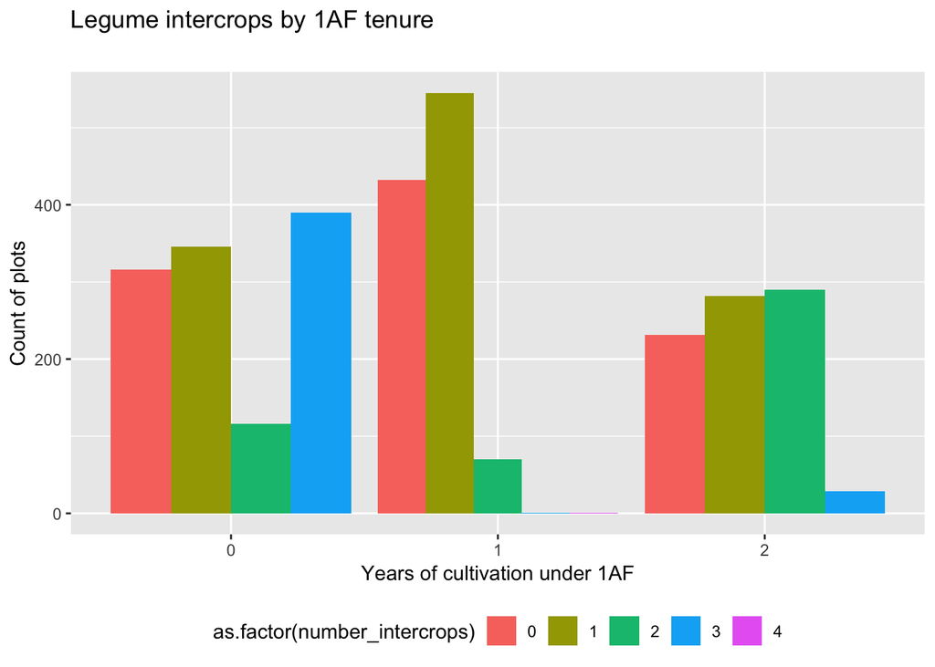

```r
intercrop_check %>%
  group_by(sample_id) %>%
  summarize(years_oaf = sum(d_client, na.rm = T),
            number_intercrops = sum(legume_intercrop, na.rm = T)) %>%
  group_by(years_oaf, number_intercrops) %>%
  tally() %>%
  filter(years_oaf < 3) %>%
  ggplot(., aes(x = as.factor(years_oaf), y = n, fill = as.factor(number_intercrops))) +
  geom_bar(stat = 'identity', position = 'dodge') +
  labs(title = "Legume intercrops by 1AF tenure", x = "Years of cultivation under 1AF", y = "Count of plots",
       subtitle = "") +
  theme(legend.position = 'bottom')
```

We’re looking for an indication that 1AF plots have fewer legume intercrops and it does appear that plots that have not been cultivated with 1AF have more years of legume intercropping (the blue bar on the left) that for plots that are 1AF plots for more seasons. This relationship is not necessarily statistically different as we also see years of numerous legume intercrops for 1AF plots as well. The main distinguishing feature however is the big bar indicating that **plots that have not been 1AF plots ever have had 3 legume intercrops**.

## What moves with nitrogen?

Consider using PCA to simplify the data into components that move in the same direction or opposite of nitrogen to understand the main relationships in the data.

```r
keySoilVars <- c("ph", "calcium", "total.nitrogen", "organic.carbon", "magnesium")
```

# Kenya models

```r
keDat <- keDat %>% mutate(age2 = age^2)


indFeList <- list("as.factor(d_client)",
                  c("as.factor(d_client)", "as.factor(sample_id)"),
                  c("as.factor(d_client)", "as.factor(sample_id)", "as.factor(season)"),
                  c("as.factor(d_client)", "as.factor(sample_id)", "as.factor(season)", "age", "age2"))


# run this in parallel to speed up the process
# load the data and variables and packages into the cluster
regFileKe <- "regFile_through2017.RData"
forceUpdate <- forceUpdateAll

if(!file.exists(regFileKe) || forceUpdate) {
library(parallel)
no_cores <- detectCores() - 1

cl <- makeCluster(no_cores, type="FORK")
clusterEvalQ(cl, "plm")
clusterExport(cl, "keDat")
clusterExport(cl, "keySoilVars")
clusterExport(cl, "indFeList")

indFeLoopKe <- parLapply(cl, indFeList, function(mod){
  lapply(keySoilVars, function(outcome){
    form = lm(reformulate(termlabels = mod, response = outcome), data=keDat)

    pdf(file=paste("output/ke2017/", paste0(outcome, paste(mod, collapse = "")), ".pdf", sep = ""))
    print(plot(form))
    dev.off()

    form = plm(form, c("sample_id", "age", "age2"))

    rownames(form) = paste(rownames(form), outcome, sep = " ")
    return(form)
  })

})
stopCluster(cl)
save(indFeLoopKe, file=regFileKe)
} else {
  load(regFileKe)
}
```

And combine model outputs into tables for each model

```r
modExportKe <- lapply(indFeLoopKe, function(models){
  do.call(rbind, models)
})


for(i in 1:length(modExportKe)){
  write.csv(modExportKe[i], file=paste0("output/ke2017/","regOutput_", i, ".csv"), row.names = T)
}
```

In the individual fixed effect model above, the naive model would only include a client indicator and individual fixed effects. If we add season, we lose significance on almost everything. I’d guess that as we add more likely controls we additionally lose significance. I’ve included age and age squared along the lines of [Hicks et.al](http://www.nber.org/papers/w23253).

```r
finalModelKe <- modExportKe[4]

kable(finalModelKe, format="markdown")
```

|  | Coefficient | 95% Confidence Interval | P-Value |
| --- | --- | --- | --- |
| (Intercept) ph | 5.5e+00 | 5 to 5.9 | <0.001 *** |
| as.factor(d_client)1 ph | -3.4e-02 | -0.089 to 0.02 | 0.22 |
| as.factor(season)2016 ph | -3.9e-01 | -0.41 to -0.37 | <0.001 *** |
| (Intercept) calcium | 5.0e+02 | -74 to 1100 | 0.088 . |
| as.factor(d_client)1 calcium | -5.1e+01 | -110 to 12 | 0.11 |
| as.factor(season)2016 calcium | -5.8e+01 | -85 to -32 | <0.001 *** |
| as.factor(season)2017 calcium | -4.4e+01 | -79 to -9.3 | 0.013 * |
| (Intercept) total.nitrogen | 1.0e-01 | 0.076 to 0.12 | <0.001 *** |
| as.factor(d_client)1 total.nitrogen | -2.7e-03 | -0.0053 to -4e-05 | 0.047 * |
| as.factor(season)2016 total.nitrogen | -9.0e-03 | -0.01 to -0.008 | <0.001 *** |
| as.factor(season)2017 total.nitrogen | -1.1e-02 | -0.012 to -0.0095 | <0.001 *** |
| (Intercept) organic.carbon | 1.2e+00 | 0.77 to 1.6 | <0.001 *** |
| as.factor(d_client)1 organic.carbon | -6.3e-04 | -0.044 to 0.043 | 0.98 |
| as.factor(season)2016 organic.carbon | -3.1e-01 | -0.33 to -0.29 | <0.001 *** |
| as.factor(season)2017 organic.carbon | -3.0e-01 | -0.33 to -0.28 | <0.001 *** |
| (Intercept) magnesium | 8.6e+01 | 14 to 160 | 0.019 * |
| as.factor(d_client)1 magnesium | -5.8e+00 | -14 to 2.5 | 0.17 |
| as.factor(season)2016 magnesium | -1.2e+01 | -15 to -8.3 | <0.001 *** |

```r
write.csv(finalModelKe, file="output/ke2017/indFe_ke2017.csv")
```

# Rwanda models

```r
rwDat <- rwDat %>% mutate(age2 = age^2)

rwDat <- do.call(data.frame,lapply(rwDat, function(x){
  replace(x, is.infinite(x),NA)
  }))
```

```r
indFeList <- list("as.factor(d_client)",
                  c("as.factor(d_client)", "as.factor(sample_id)"),
                  c("as.factor(d_client)", "as.factor(sample_id)", "as.factor(season)"),
                  c("as.factor(d_client)", "as.factor(sample_id)", "as.factor(season)", "age", "age2"))


# run this in parallel to speed up the process
# load the data and variables and packages into the cluster
regFileRw <- "regFile_through2017b.RData"
#forceUpdate <- forceUpdateAll

if(!file.exists(regFileRw) || forceUpdate) {
library(parallel)
no_cores <- detectCores() - 1

cl <- makeCluster(no_cores, type="FORK")
clusterEvalQ(cl, "plm")
clusterExport(cl, "rwDat")
clusterExport(cl, "keySoilVars")
clusterExport(cl, "indFeList")

indFeLoopRw <- parLapply(cl, indFeList, function(mod){
  lapply(keySoilVars, function(outcome){

    form = lm(reformulate(termlabels = mod, response = outcome), data=rwDat)

    pdf(file=paste("output/rw2017b/", paste0(outcome, paste(mod, collapse = "")), ".pdf", sep = ""))
    print(plot(form))
    dev.off()

    form = plm(form, c("sample_id", "age", "age2"))

    rownames(form) = paste(rownames(form), outcome, sep = " ")
    return(form)
  })

})
stopCluster(cl)
save(indFeLoopRw, file=regFileRw)
} else {
  load(regFileRw)
}

modExportRw <- lapply(indFeLoopRw, function(models){
  do.call(rbind, models)
})

for(i in 1:length(modExportRw)){
  write.csv(modExportRw[i], file=paste0("output/rw2017b/","regOutput_", i, ".csv"), row.names = T)
}

finalModelRw <- modExportRw[4]

kable(finalModelRw, format="markdown")
write.csv(finalModelRw, file="output/rw2017b/indFe_rw2017.csv")
```

[output not shown]

# Appendix

Nothing to see here